# Session4: File I/O

Yura Song and Sumeet Pal Singh  
13 April, 2020

Notes by: Yura Song

### Course Organization

- YouTube Live Stream accessible for later
- Github site for course: https://github.com/sumeetpalsingh/R_course/
- Time-table (All sessions at 5 pm Brussels Time)

| Data | Day | Topic |
| --- | --- | --- |
| 13 April | Monday | File I/O |
| 15 April | Wednesday | Data Plotting |
| 20 April | Monday | R Markdown |
| 23 April | Thursday | R Shiny Apps |

### File I/O

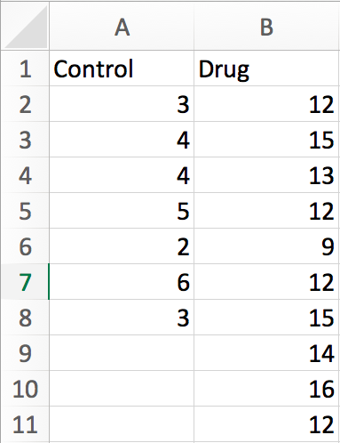

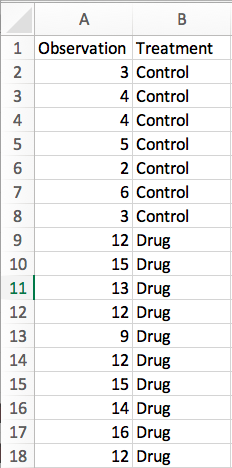

### Useful functions

- setwd(“dir”): Set working (current) directory
- readr::read_csv(“file”) Read csv files
- readxl::
  - read_xls(“file”): Read .xls excel file
  - read_xlsx(“file”): Read .xlsx excel file
  - read_excel(“file”): Read .xls / .xlsx excel file
- write_csv(x = data, path = “file”): Save data to csv file

### Wide Format

```r
require(readxl)
require(tidyverse)
Expe <- read_xls(path = "Session4 Files/ExperimentTwoDrugs.xls")
Expe
```

```
# A tibble: 13 x 3
   Control Drug1 Drug2
     <dbl> <dbl> <dbl>
 1       3    12     6
 2       4    15     4
 3       4    13     8
 4       5    12     6
 5       2     9     8
 6       6    12     6
 7       3    15     7
 8      NA    14    10
 9      NA    16    13
10      NA    12     7
11      NA    NA     9
12      NA    NA     6
13      NA    NA     5
```

### Wide to Tidy Format

```r
Expe %>%
  pivot_longer(cols = , everything(),
               ## Name of column that will get the group / feature information
               names_to = "Treatment",
               ## Name of column that will get values
               values_to = "Cells") %>%
  drop_na %>%
  arrange(Treatment) ->
  Expe
Expe
```

```
# A tibble: 30 x 2
   Treatment Cells
   <chr>     <dbl>
 1 Control       3
 2 Control       4
 3 Control       4
 4 Control       5
 5 Control       2
 6 Control       6
 7 Control       3
 8 Drug1        12
 9 Drug1        15
10 Drug1        13
# … with 20 more rows
```

### Wide Format (Linked data)

```r
Experiment <- read_xls(path = "Session4 Files/ExperimentWithFeatures.xls",
                       sheet = 1)
glimpse(Experiment, width = 50)
```

```
Rows: 10
Columns: 7
$ Cells_Control  <dbl> 3, 4, 4, 5, 2, 6, 3, NA,…
$ Age_Control    <dbl> 32, 34, 21, 53, 13, 12, …
$ Gender_Control <chr> "F", "M", "F", "M", "M",…
$ Cells_Drug     <dbl> 12, 15, 13, 12, 9, 12, 1…
$ Age_Drug       <dbl> 12, 6, 45, 76, 65, 34, 5…
$ Gender_Drug    <chr> "M", "F", "M", "F", "F",…
$ Day            <chr> "Mo", "Mo", "Tu", "Tu", …
```

### Wide to Tidy Format (Linked data)

```r
pivot_longer(data = Experiment,
             cols = -Day,
             names_to = c(".value", "Treatment"),
             names_sep = "_") %>%
  drop_na() %>%
  arrange(Treatment) %>%
  mutate_if(is.character, as.factor) ->
  Experiment
glimpse(Experiment, width = 50)
```

```
Rows: 17
Columns: 5
$ Day       <fct> Mo, Mo, Tu, Tu, Tu, Tu, We, M…
$ Treatment <fct> Control, Control, Control, Co…
$ Cells     <dbl> 3, 4, 4, 5, 2, 6, 3, 12, 15, …
$ Age       <dbl> 32, 34, 21, 53, 13, 12, 35, 1…
$ Gender    <fct> F, M, F, M, M, F, F, M, F, M,…
```

### Functions in R

- name_fn <- function(attributes){  
  function_body  
  return(object) ## The object will be returned  
  }
- save function in a file: fn_file.R
- load the functions using: source(“fn_file.R”) ## Make sure the file is in the current path

### Functions to save data structure

- save(data, file = “file.RData”): writes an external representation of R data
- saveRDS(data, file = file.rds): write a single R object to a file
- save.image(file = “file.RData”): saves the current environment
- savehistory(file = “.Rhistory”): saves the commands history

### To Remove an object from the environment

- remove(object)
- remove(list = ls()): Removes all objects
- gc(): Clear RAM after removal of object